# Gaussian process emulation

Ciarán McInerney

2023-06-26

#### Requisites

```r
# Load packages.
library(tidyverse)
library(RobustGaSP)
library(FME)
library(plotly)
# Set seed.
set.seed(1)
```

## TL;DR

**Emulators are models of models, where models are just simplified representations of something. People often make emulators of simulators when their simulators are too costly to run as often as they’d like. A good emulator is one that can produce outputs sufficiently similarly to what the underlying simulation would produce, for the same inputs. You can use any modelling approach as an emulator, keeping in mind that you want your emulator to be simpler, faster, and/or cheaper than the model it is emulating. Gaussian processes are a common choice but even [random forests have been used as simplified representations of ocean trophic models](https://www.stat.colostate.edu/~hooten/papers/pdf/Hooten_etal_JABES_2011.pdf).**  
**Benefits of Gaussian process emulators include**

1. **in addition to providing outputs from a simpler model, they provide likely functions that satisfy the input-output relationship, and**
2. **they inherently quantify the uncertainty of emulations.**

## Why?

So, what is the motivation behind Gaussian processes emulators?  
First of all, if you want to know about Gaussian processes, you can [check out my other explainer](https://github.com/ciaranmci/SoMaS). For now, it suffices to know that they are the statistical foundation upon which Gaussian process emulators are based - go figure!  
Emulators are just models, but the term is usually used to indicate that the model in question is a model of a model, rather than a model of reality. You might want to make an emulator when the underlying model is too expensive to run. As I hoped you have guessed, the emulator really should be less expensive to run than the underlying model, otherwise you are wasting your time.  
The origin of emulation is often said to arise from the work of Jerome Sacks and friends in their “[Design and Analysis of Computer Experiments](https://sci-hub.wf/https://www.jstor.org/stable/2245858)”. The Bayesian approach was then developed and promoted by Carla Currin and her pals. An academic summary can be found in [Currin et al. (1991)](https://sci-hub.wf/https://www.jstor.org/stable/2290511) which builds a bit on their previous work in [Currin et al. (1989)](https://technicalreports.ornl.gov/cpr/rpt/6863.pdf).

## Seriously, what?

I like [Andrianakis et al.](https://journals.plos.org/ploscompbiol/article/file?id=10.1371/journal.pcbi.1003968&type=printable)’s description of emulators as Bayesian representations of a simulator. It communicates two key notions:

1. that the emulator isn’t trying to model the simulator with fidelity - and definitely not model reality with fidelity, and
2. that the emulator is based in abstract probabilistic relations between the inputs and outputs.

A Gaussian process emulator is trying to find the functions that fit a given set of input-output tuples. Even though Euclid tells us that there is only one straight line that passes through two points, there are an infinite number of functions that can. A Gaussian process emulator leverages traits of Gaussian processes to fit all of these functions. As I note in [my Gaussian processes explainer](https://github.com/ciaranmci/SoMaS), the trick is to think of each value of your inputs to have its own Gaussian distribution. If I make a few assumptions about how these value-specific distributions linearly combine, then I can infer the distributions of the input values that I haven’t observed yet.  
Looking at the plot below, you will see that I’ve fitted a Gaussian process emulator to some input-output tuples. The hollow circles indicate input-output tuples that I observed and used to train the emulator, and the black line is the smooth, mean function that the emulator suggested. The grey bulges indicate the emulator’s uncertainty around it’s mean emulation.

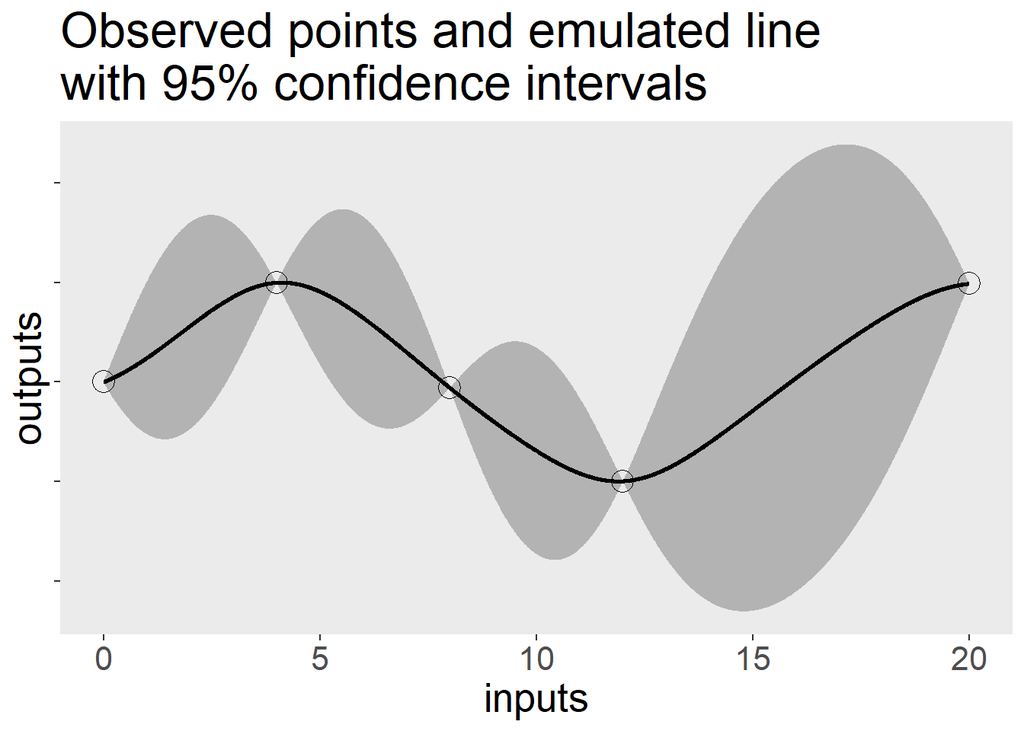

```r
# Generate some fake data.
inputs <- seq(from = 0, to = 20, by = 4)
inputs <- inputs[c(1:4,6)]
outputs <- sin(inputs * 0.4)
df_sim <- data.frame(inputs, outputs)
# Fit a Gaussian process emulator.
mod_GPE <-
  RobustGaSP::rgasp(design = inputs,
                    response = outputs)
predict_input <-
  data.frame( inputs = seq(from = min(inputs), to = max(inputs), by = 0.01))
df_GP <-
  data.frame(
      predict_input = predict_input,
      model_prediction = predict(mod_GPE, predict_input)
    )
# Plot.
(p_GPE <-
  ggplot() +
    geom_ribbon(data = df_GP, aes(x = inputs, ymin = model_prediction.lower95, ymax = model_prediction.upper95), fill = "grey70") +
    geom_point(data = df_sim, aes(x = inputs, y = outputs), size = 5, shape = 1) +
    geom_line(data = df_GP, aes(x = inputs, y = model_prediction.mean), linewidth = 1) +
    labs(title = "Observed points and emulated line\nwith 95% confidence intervals") +
    theme(panel.grid.major = element_blank(),
          panel.grid.minor = element_blank(),
          axis.text.y = element_blank(),
          text = element_text(size = 20))
)
```

There are two things I want you take away from this plot:

1. Note that the clouds of uncertainty disappear at the points where we have observed the input-output relationship, but expand in the regions between.
2. Note that the cloud of uncertainty around the region of $12\le x \le 20$ is larger than elsewhere.

By considering these to notes, it should be clear that our emulator will only be as good and as certain as the quality, quantity, and range of the observations used to fit it. This is true for any model, though I’ve heard some people talk about Gaussian process emulators as if they magically make bad data good - perhaps because it makes for pleasant smooth curves…sometimes.  
So what is a Gaussian process emulator? It is a model of a model, where the higher-level model uses traits of Gaussian processes to provide the distributions of all functions that satisfy our observations. Emulators are not restricted to Gaussian processes, though. For example, [Hooten et al.](https://www.stat.colostate.edu/~hooten/papers/pdf/Hooten_etal_JABES_2011.pdf) use random forests as their emulator.

### …and what are covariance functions?

I discuss covariance functions in [my Gaussian processes explainer](https://github.com/ciaranmci/SoMaS). I won’t go into too much detail here because I find that many resources online confuse Gaussian processes with Gaussian process emulators, and sometimes make things worse by called them Gaussian process regressions. Covariance functions are an fundamental attribute of Gaussian processes, but are just a design choice for emulators - just another dial to twist and tune. My most-succinct explanation is that covariance functions are a hyperparameter that dictates the smoothness of your emulation by specifying how the outputs should relate to each other. You can think of it as specifying the correlation between adjacent and distant values on the fitted curve.  
One additional piece of information that you might find useful is that the word “covariance” is sometimes swapped for “correlation”, and they are also often called kernels, just like those used in support vector machines.

## How?

To illustrate a Gaussian process emulator, I’ll use the two-input toy example from [Bastos and O’Hagan](https://sci-hub.wf/10.1198/tech.2009.08019).  
Each of $n$ iterations, $i=(1, 2, \ldots , n)$, of the simulation takes two real-numbered inputs, $a$ and $b$, with range between 0 and 1 inclusive, to produce an output, $y$, according to the function

$$y = (1-e^{-\frac{1}{2b}})
\left(\frac{2300a^3+1900a^2+2092a+60}{100a^3+500a^2+4a+20}\right)$$

I’ll fit a Gaussian process emulator on the inputs and outputs of 20 simulations; these 20 tuples will provide the ‘train’ dataset. I’ll assess my Gaussian process emulator on a separate set of inputs and outputs from another 25 simulations; these 25 tuples will provide the ‘test’ dataset. The values for inputs will be selected by latin hypercube sampling.  
Let’s crunch those numbers and view the first few tuples of $(a, b, y)$.

```r
# Set simulation parameters.
n_train <- 20
n_test <- 25
# Set input values.
possVals <- data.frame(min = c(0, 0), max = c(1, 1))
rownames(possVals) <- c("a", "b")
df_GPE_train <- FME::Latinhyper(possVals, n_train) %>% data.frame()
df_GPE_test <- FME::Latinhyper(possVals, n_test) %>% data.frame()
# Calculate and append output values.
df_GPE_train <-
  df_GPE_train %>%
  dplyr::mutate(
    y =
      (
      1 - exp(-(1 / (2*b)) )
    ) *
      (
        sum( (2300*a^3), (1900*a^2), (2092*a), 60 ) /
          sum( (100*a^3), (500*a^2), (4*a), 20 )
      )
  )
df_GPE_test <-
  df_GPE_test %>%
  dplyr::mutate(
    y =
      (
      1 - exp(-(1 / (2*b)) )
    ) *
      (
        sum( (2300*a^3), (1900*a^2), (2092*a), 60 ) /
          sum( (100*a^3), (500*a^2), (4*a), 20 )
      )
  )
# Display first few tuples of training dataset.
knitr::kable(head(df_GPE_train))
```

| a | b | y |
| --- | --- | --- |
| 0.4967353 | 0.3456438 | 8.865028 |
| 0.5606071 | 0.7146802 | 5.834341 |
| 0.2325837 | 0.7729533 | 5.522402 |
| 0.5062778 | 0.6666197 | 6.117646 |
| 0.0133610 | 0.8325435 | 5.234677 |
| 0.0693057 | 0.9629008 | 4.696036 |

All looks good so let’s continue.  
I will use a Gaussian covariance / correlation function (a.k.a. a kernel) to define how any two given values of an input - i.e. either $a$ and $a^{\prime}$, or $b$ and $b^{\prime}$ - co-vary. If we only had a one-dimensional input, $a$, then the Gaussian covariance function would simply be

$$C(a, a^{\prime},\psi_{a})=exp \left( - \left( \frac{a-a^{\prime}}
{\psi_{a}} \right)^2 \right)$$

$$C((a, b), (a^{\prime}, b^{\prime}), (\psi_{a}, \psi_{b})) =exp \left( -
\left( \frac{a-a^{\prime}} {\psi_{a}} \right)^2 - \left(
\frac{b-b^{\prime}} {\psi_{b}} \right)^2\right)$$

So, let’s fit the emulator to the predictions and see what we get.

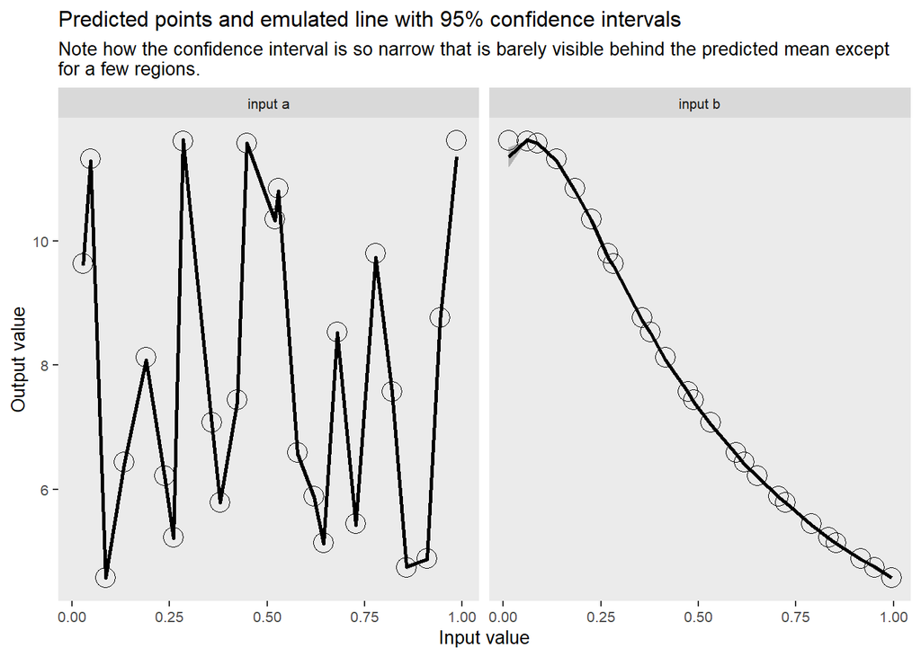

```r
# Fit model using 'train' data.
model <-
  DiceKriging::km(design = data.frame(df_GPE_train %>% dplyr::select(a, b)),
                  response = data.frame(y = df_GPE_train$y),
                  covtype = "gauss")
# Predict values using 'test' data.
model_predict <-
  predict(model,
          newdata = df_GPE_test %>% dplyr::select(a, b),
          type = "SK")
# Prepare plotting data.
df_GPE_predict <-
  df_GPE_test %>%
  dplyr::mutate(
    predicted_mean = model_predict$mean,
    predicted_upper95 = model_predict$upper95,
    predicted_lower95 = model_predict$lower95,
  )
df_GPE_predict <-
  dplyr::bind_rows(
    df_GPE_predict %>%
      dplyr::select(x = a, y, predicted_mean, predicted_upper95, predicted_lower95) %>%
      dplyr::mutate(group = "input a"),
    df_GPE_predict %>%
      dplyr::select(x = b, y, predicted_mean, predicted_upper95, predicted_lower95) %>%
      dplyr::mutate(group = "input b"),
    )
# Plot all ys for every x in the simulations, overlay the mean GPE prediction,
# and overlay the 95% confidence intervals for the prediction.
(p_GPE_predict <-
  df_GPE_predict %>%
  ggplot() +
    geom_ribbon(aes(x = x, ymin = predicted_lower95, ymax = predicted_upper95), fill = "grey70") +
    geom_point(aes(x = x, y = y), size = 5, shape = 1) + # Test points.
    geom_line(aes(x = x, y = predicted_mean), linewidth = 1) + # Predicted mean.
    labs(x = "Input value", y = "Output value",
         title = "Predicted points and emulated line with 95% confidence intervals",
         subtitle = "Note how the confidence interval is so narrow that is barely visible behind the predicted mean except\nfor a few regions.") +
    facet_wrap(~group) +
    theme(panel.grid.major = element_blank(),
          panel.grid.minor = element_blank(),
          text = element_text(size = 10))
)
```

### But is it any good?

Just because you can, doesn’t mean you should. If we use Gaussian process emulators, then we should evaluate how well they are emulating the simluation of the real world, rather than just assuming that they are representing the real-world well. Never forget that emulators are models of models - that’s twice removed from the reality about which we want to make inference.  
A worthwhile read on this topic is [Leonardo Bastos](https://scholar.google.com/citations?user=A5VmZYMAAAAJ&hl=en&oi=sra) and [Anthony O’Hagan](https://scholar.google.com/citations?user=CljxR1UAAAAJ&hl=en&oi=sra)‘s 2009 paper on “[Diagnostics for Gaussian process emulators](https://sci-hub.wf/10.1198/tech.2009.08019)”, which they wrote during their time at University of Sheffield. The fundamental idea is that models’ validity is usually assessed by comparing observations to predictions, but these are one and the same for emulators. The trick is to notice that the observations from the simulator and the predictions from the emulator are only the same for the observations used to ‘train’ / fit the emulator. A ‘test’ set of observations can be provided by generating new observations from the simulator that the emulator has never seen. Then, all that is needed is a suitable distance measure and maybe a decision rule to indicate if the emulator is sufficient.  
The importance of a “suitable” distance measure cannot be underestimated. If our simulator or our emulator output is a smooth function, then there is dependence between successive values. Any distance measure that assumes *independence* between observations would not be suitable, rendering the assessment of emulator validity invalid!  
I particularly like [Bastos and O’Hagan](https://sci-hub.wf/10.1198/tech.2009.08019)‘s choice of pivoted Cholesky decomposition of the Mahalanobis distance between simulator and emulator outputs for a given set of ’test’ inputs unseen by the emulator during ‘training’ / fitting.

[figure not shown]

```r
knitr::include_graphics("https://media.giphy.com/media/3oKHWa8DyEfPc3baCc/giphy.gif")
```

Ok, that was a bit of a mouthful. To be fair, the concept is a bit of a headful but let me try to give you the gist, in a few bullet points:

- The Mahalanobis distance, $D_{Mahalanobis}$ , is a way of measuring the distance from a point to a distribution of points. This makes it suitable to our situation of comparing a single outcome observation to the posterior distribution of outcomes provided by our Gaussian process emulator.
- The Mahalanobis distance makes use of [principal components](https://en.wikipedia.org/wiki/Principal_component), which enables it to handle dependence between data points. This makes it suitable to our situation where the simulation or emulator are smooth functions.
- The Mahalanobis distance can be decomposed into the dot product of a vector of transformed errors, $\textbf{A}$, and its transpose, $\textbf{A}^T$: $D_{Mahalanobis} = A^TA$.
  - The “error” in this case is the difference between the simulated and the emulated outputs using the unseen ‘test’ inputs.
  - The errors can be transformed in variety of ways by some matrix $\textbf{B}$ to ensure, for example, uncorrelated elements with unit variances. All that matters is that $\textbf{A}=\textbf{B}(output_{simulation,\ 'test'}-output_{emulation,\ 'test'})$.
- A [Cholesky deomposition](https://en.wikipedia.org/wiki/Cholesky_decomposition) of the variance of emulations gives us a computationally-efficient transformation matrix to use. Better still, a *pivoted* Cholesky decomposition sorts the pivots such that the first refers to emulated values with the largest variance, the second refers to emulated values with the second-largest, etc.
- Bastos and O’Hagan argue that the first few pivots relate to (non-)homogeneity of emulations for a given input or non-stationarity, and the latter pivots relate to the appropriateness of the correlation structure we specified for our emulator.
- This all makes for a decomposition and distance measure that enable us to distinguish the source of any poor emulation.

Bastos and O’Hagan aren’t the first to know about decomposing Mahalanobis distances; they just leveraged insight from [Myung Geum Kim](https://sci-hub.wf/10.1080%2F03610920008832559) some nine years earlier.  
What are some of the other ways to check the emulation? if you really want to be thorough, try some of these:

- A histogram and summary statistics of the Mahalanobis distances gives an idea of the distribution of emulator performance.
- Plotting emulator errors against the index of pivots from the pivoted Cholesky decomposition should show a spread around 0 and constant variance, testing homogeneity, stationarity, and appropriateness of the correlation structure.
- A run-of-the-mill Q-Q plot of the uncorrelated standardised errors tests our assumption that simulator outputs were Gaussian distributed.
- Plotting the distribution of emulator errors against their respective input values tests for patterns of emulation errors for particular portions of the input space.

## Final thoughts and other resources

Gaussian process emulators are very versatile, can tell us the probability of fitted functions, and give us an idea of the uncertainty associated with its emulations. Cynically, I could say that the validity of the emulator models is questionable given the assumptions, but many people have found them useful, regardless, so it looks like they are robust.

### It ain’t magic

[As I noted in my explainer of Gaussian processes](https://github.com/ciaranmci/SoMaS), they are not some sort of magic that frees the user of difficult decisions just because it replaces a resource-consuming simulation. These “difficult decisions” I’m talking about are the assumptions that a method relies on. One assumption of a Gaussian process emulator is that each point in the simulation being emulated is Gaussian distributed and [stationary](https://en.wikipedia.org/wiki/Stationary_process) over the duration being simulated. This is only justified if the underlying data-generating phenomenon is in a consistent / stable state rather than switching between different states, or worse still, ever-changing. The variance we observe must be due to randomness, only.  
In the case of climate modelling, it is arguable that the Gaussian process emulation’s assumption of stationarity will only be valid for emulating simulations based on stable physical laws, rather than, say, some well-fitted-but-merely-a-proxy simulation. To ponder more about this issue of proxy models, I highly recommend the fourth chapter of Richard McElreath’s book “[Statistical Rethinking](https://xcelab.net/rm/statistical-rethinking/)” or watching [its accompanying lecture recording](https://youtu.be/tNOu-SEacNU).

### Is it normal?

I’m glad [Bastos and O’Hagan](https://sci-hub.wf/10.1198/tech.2009.08019) note that

> “the emulator asserts that it is very unlikely for the true simulator output to be more than two or three predictive standard deviations from the predictive mean, and that it is no more likely to be above the predictive mean than below it”

In a world of [complex adaptive systems](https://youtu.be/GjwvsK-6640), [black swans](https://en.wikipedia.org/wiki/Black_swan_theory), [heavy- and long- tailed distributions](https://youtu.be/vIp1kY0H0yw), and [scale-free distributions](https://youtu.be/pYMsI-8GsxI), are Gaussian assumptions appropriate? The Gaussian assumptions can be checked using, for example, Q-Q plots of the uncorrelated standardised errors and interpretting as usual (i.e. points on the lines means good).

### Resources

1. For a good introduction to Gaussian process emulation, check our University of Bristol’s offer (https://compass.blogs.bristol.ac.uk/2022/01/25/gaussian-process-emulation/).
2. distill.pub publications also have a blog by [Agnihotri and Batra](https://distill.pub/2020/bayesian-optimization/) on Bayesian optimization that references Krige’s initial work.
3. Section 2.2 of [Bastos and O’Hagan](https://sci-hub.wf/10.1198/tech.2009.08019) covers other problems with Gaussian process emulators.